# R Project

This is a Notebook for data science with R project.

import library

```r
library(ggplot2)
```

check the location

```r
getwd()
```

```
## [1] "C:/Users/Asus/Desktop"
```

start solving the problems,

Q1 - The team wants to analyze each variable of the data collected through data summarization to get a basic understanding of the dataset and to prepare for further analysis.

- read data and print the summary

```r
data<-read.csv("1555058318_internet_dataset.csv",header = TRUE,sep=";")


summary(data)
```

```
##    ï..Bounces         Exits            Continent
##  Min.   : 0.000   Min.   : 0.000   AF       :  321
##  1st Qu.: 0.000   1st Qu.: 1.000   AS       : 3171
##  Median : 1.000   Median : 1.000   EU       : 6470
##  Mean   : 0.713   Mean   : 0.906   N.America:20043
##  3rd Qu.: 1.000   3rd Qu.: 1.000   OC       : 1356
##  Max.   :30.000   Max.   :36.000   SA       :  748
##
##                      Sourcegroup      Timeinpage       Uniquepageviews
##  google                    :11542   Min.   :    0.00   Min.   : 1.000
##  (direct)                  : 7532   1st Qu.:    0.00   1st Qu.: 1.000
##  Others                    : 5360   Median :    0.00   Median : 1.000
##  tableausoftware.com       : 2388   Mean   :   73.18   Mean   : 1.114
##  t.co                      : 2249   3rd Qu.:   10.00   3rd Qu.: 1.000
##  public.tableausoftware.com: 1354   Max.   :46745.00   Max.   :45.000
##  (Other)                   : 1684
##      Visits         BouncesNew
##  Min.   : 0.000   Min.   :0.00000
##  1st Qu.: 1.000   1st Qu.:0.00000
##  Median : 1.000   Median :0.01000
##  Mean   : 0.906   Mean   :0.00713
##  3rd Qu.: 1.000   3rd Qu.:0.01000
##  Max.   :45.000   Max.   :0.30000
##
```

data type

```r
str(data)
```

```
## 'data.frame':    32109 obs. of  8 variables:
##  $ ï..Bounces     : int  0 0 0 0 0 0 0 0 0 0 ...
##  $ Exits          : int  0 0 0 0 0 0 0 0 0 0 ...
##  $ Continent      : Factor w/ 6 levels "AF","AS","EU",..: 5 4 4 4 4 4 4 4 5 2 ...
##  $ Sourcegroup    : Factor w/ 9 levels "(direct)","facebook",..: 1 1 4 5 5 5 5 1 1 4 ...
##  $ Timeinpage     : int  18 4 35 70 81 75 186 710 712 344 ...
##  $ Uniquepageviews: int  1 1 1 1 1 1 1 1 1 1 ...
##  $ Visits         : int  0 0 0 0 0 0 0 0 1 1 ...
##  $ BouncesNew     : num  0 0 0 0 0 0 0 0 0 0 ...
```

Q2 - As mentioned earlier, a unique page view represents the number of sessions during which that page was viewed one or more times. A visit counts all instances, no matter how many times the same visitor may have been to your site. So the team needs to know whether the unique page view value depends on visits.

- we need to get the correlation between them

```r
cor(data$Uniquepageviews, data$Visits)
```

```
## [1] 0.8144457
```

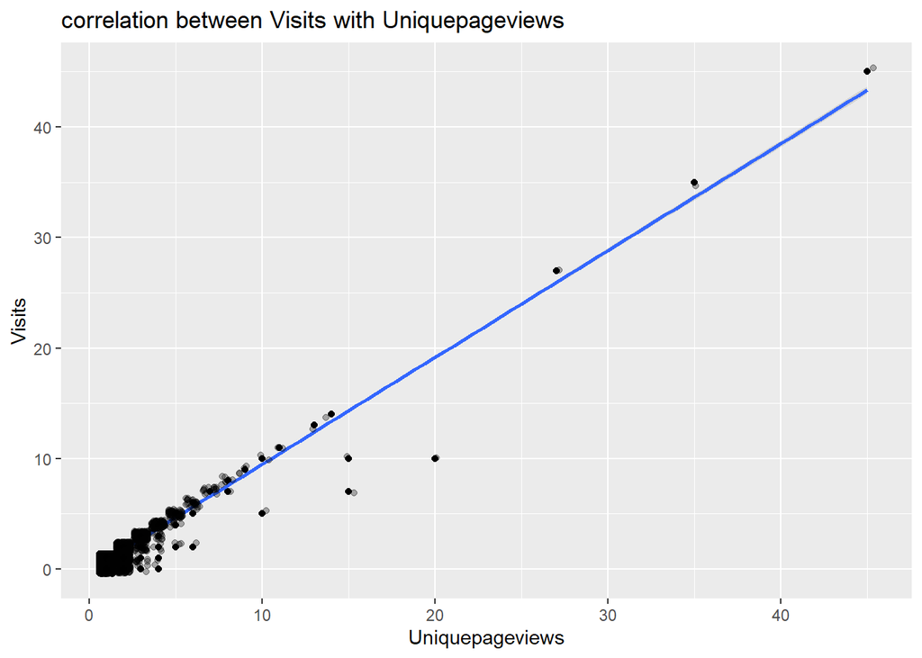

```r
ggplot(data= data, aes(x=data$Uniquepageviews, y= data$Visits ))+
       geom_point()+geom_smooth(method='lm',alpha = 0.3)+
       ggtitle("correlation between Visits with Uniquepageviews")+xlab("Uniquepageviews")+
     geom_jitter( alpha = .3)  +
       ylab("Visits")
```

- we can see they have a high correlation, let us perform ANOVA of Unique Pageviews with all variables

```r
ANOVA<-aov(Uniquepageviews~., data=data)
summary(ANOVA)
```

```
##                Df Sum Sq Mean Sq  F value Pr(>F)
## ï..Bounces      1   5273    5273 56140.38 <2e-16 ***
## Exits           1   2326    2326 24761.25 <2e-16 ***
## Continent       5     26       5    56.24 <2e-16 ***
## Sourcegroup     8    131      16   173.84 <2e-16 ***
## Timeinpage      1    164     164  1741.53 <2e-16 ***
## Visits          1   1205    1205 12826.12 <2e-16 ***
## Residuals   32091   3014       0
## ---
## Signif. codes:  0 '***' 0.001 '**' 0.01 '*' 0.05 '.' 0.1 ' ' 1
```

- It has a significant impact on the variables—source group, bounces, continent, visits, and time on page

Q3 - Find out the probable factors from the dataset, which could affect the exits. Exit Page Analysis is usually required to get an idea about why a user leaves the website for a session and moves on to another one. Please keep in mind that exits should not be confused with bounces.

- apply ANOVA test

```r
ANOVA<-aov(Exits~.,data = data)
summary(ANOVA)
```

```
##                    Df Sum Sq Mean Sq   F value   Pr(>F)
## ï..Bounces          1  10578   10578 1.043e+05  < 2e-16 ***
## Continent           5      3       1 5.960e+00 1.62e-05 ***
## Sourcegroup         8      7       1 8.760e+00 4.89e-12 ***
## Timeinpage          1    130     130 1.279e+03  < 2e-16 ***
## Uniquepageviews     1   1573    1573 1.552e+04  < 2e-16 ***
## Visits              1      1       1 5.014e+00   0.0251 *
## Residuals       32091   3254       0
## ---
## Signif. codes:  0 '***' 0.001 '**' 0.01 '*' 0.05 '.' 0.1 ' ' 1
```

- we can see the variables source group, bounces, unique pageviews, continent, visits, and time on page affect the exits variable.

Q4 - Every site wants to increase the time on page for a visitor. This increases the chances of the visitor understanding the site content better and hence there are more chances of a transaction taking place. Find the variables which possibly have an effect on the time on page.

- apply ANOVA test

```r
ANOVA<-aov(Timeinpage~.,data = data)
summary(ANOVA)
```

```
##                    Df    Sum Sq   Mean Sq  F value   Pr(>F)
## ï..Bounces          1 5.947e+07  59466495  422.868  < 2e-16 ***
## Exits               1 1.304e+08 130400662  927.283  < 2e-16 ***
## Continent           5 4.767e+06    953431    6.780 2.51e-06 ***
## Sourcegroup         8 1.545e+06    193153    1.374    0.202
## Uniquepageviews     1 1.791e+08 179133934 1273.826  < 2e-16 ***
## Visits              1 1.073e+08 107321113  763.163  < 2e-16 ***
## Residuals       32091 4.513e+09    140627
## ---
## Signif. codes:  0 '***' 0.001 '**' 0.01 '*' 0.05 '.' 0.1 ' ' 1
```

Q5 - A high bounce rate is a cause of alarm for websites which depend on visitor engagement. Help the team in determining the factors that are impacting the bounce.

- we need to perform logistic regression to know the variables that have an impact on the bounces.
- change the bounces to nmrical

```r
data$ï..Bounces=data$ï..Bounces*0.01
```

```r
model<-glm(ï..Bounces~Timeinpage+Continent+Exits+Sourcegroup+Uniquepageviews+Visits,data = data,family=binomial())
summary(model)
```

```
##
## Call:
## glm(formula = ï..Bounces ~ Timeinpage + Continent + Exits + Sourcegroup +
##     Uniquepageviews + Visits, family = binomial(), data = data)
##
## Deviance Residuals:
##      Min        1Q    Median        3Q       Max
## -2.26149  -0.02406   0.00206   0.00895   1.81288
##
## Coefficients:
##                                         Estimate Std. Error z value
## (Intercept)                           -4.9667681  0.6784678  -7.321
## Timeinpage                            -0.0010294  0.0005774  -1.783
## ContinentAS                            0.0022768  0.6932044   0.003
## ContinentEU                           -0.0069240  0.6786600  -0.010
## ContinentN.America                     0.0101334  0.6674188   0.015
## ContinentOC                            0.0201123  0.7333671   0.027
## ContinentSA                            0.0237507  0.7914250   0.030
## Exits                                  1.3907608  0.3356504   4.143
## Sourcegroupfacebook                   -0.0241949  1.1045171  -0.022
## Sourcegroupgoogle                     -0.0783631  0.1720157  -0.456
## SourcegroupOthers                     -0.0767919  0.2182692  -0.352
## Sourcegrouppublic.tableausoftware.com -0.2528285  0.4923123  -0.514
## Sourcegroupreddit.com                 -0.0092792  0.4709304  -0.020
## Sourcegroupt.co                        0.0148690  0.2760157   0.054
## Sourcegrouptableausoftware.com        -0.1129305  0.3190762  -0.354
## Sourcegroupvisualisingdata.com        -0.0822525  0.4614866  -0.178
## Uniquepageviews                       -3.2363108  0.5791664  -5.588
## Visits                                 2.1941121  0.5202216   4.218
##                                       Pr(>|z|)
## (Intercept)                           2.47e-13 ***
## Timeinpage                              0.0746 .
## ContinentAS                             0.9974
## ContinentEU                             0.9919
## ContinentN.America                      0.9879
## ContinentOC                             0.9781
## ContinentSA                             0.9761
## Exits                                 3.42e-05 ***
## Sourcegroupfacebook                     0.9825
## Sourcegroupgoogle                       0.6487
## SourcegroupOthers                       0.7250
## Sourcegrouppublic.tableausoftware.com   0.6076
## Sourcegroupreddit.com                   0.9843
## Sourcegroupt.co                         0.9570
## Sourcegrouptableausoftware.com          0.7234
## Sourcegroupvisualisingdata.com          0.8585
## Uniquepageviews                       2.30e-08 ***
## Visits                                2.47e-05 ***
## ---
## Signif. codes:  0 '***' 0.001 '**' 0.01 '*' 0.05 '.' 0.1 ' ' 1
##
## (Dispersion parameter for binomial family taken to be 1)
##
##     Null deviance: 234.937  on 32108  degrees of freedom
## Residual deviance:  96.514  on 32091  degrees of freedom
## AIC: 506.56
##
## Number of Fisher Scoring iterations: 11
```

- form the result we can see that the exits,visits and Unique page views has more impact on the Bounces